# Data Professional Salary Survey

Jason Tompkins

1/18/2021

The data are the result of three surveys completed in 2017, 2018, and 2019. The original source of the data was brentozar.com . Brent Ozar is a Database Administrator and online content creator. The data set contains 6893 observations of 29 variable. One thing to note about survey data is that the responses carry the biases of the respondents. Rather than approaching this data as information that was gathered by a uniform process, it is more precise to approach it as the information that respondents want to convey. In this context it is possible that respondents reported their salaries as slightly higher or responded humorously to a question that they found unimportant. For example one survey taker reported their gender as an “Apache helicopter”. This doesn’t invalidate the fact that the majority of respondents identified as male.

The analysis below seeks to answer the question “Can this data be used to gain insight into attributes that result in a higher than average salary for Data Professionals”.

## Exploratory Data Analysis

Descriptive statistics were calculated (shown below). It became obvious early on that some extreme outliers were making it difficult to analyze the data, and in some cases impossible to visualize. The salaries above $500,000 and below $1000 were removed to better facilitate analysis. The outliers were inspected, but the attributes were consistent with observations with salaries closer to the average. It’s likely that the qualities of these individuals that demand such a high salary were not captured by the survey.

- Before removing outliers
  - The average salary is $92,458.66
  - The std dev of salaries is $55,765.26
  - The median salary is $90,000.00
  - The maximum salary is $1,450,000
  - The minimum is 0
  - The middle 50% of salaries fall between $65,000 to $115,000
- After removing outliers
  - The average salary is $91,151.88
  - The std dev of salaries is $41,425.04
  - The median salary is $90,000.00
  - The maximum salary is $500,000
  - The minimum is $1050
  - The middle 50% of salaries fall between $65,000 to $115,000

A few visualizations were generated to better understand the data. The majority of respondents were full time employees, had a bachelor’s degree, and work in the private sector. Next, a histogram was created to visualize the distribution of salaries. The distribution is skewed towards the average salary of $91,151.88 with a long tail toward the maximum salary of $500,000.

A box plot was produced to create a comparison between the salaries of data professionals that worked with different database platforms. The majority respondents work with Microsoft SQL Server, but the respondents who work with databases like MongoDB and Elasticsearch seem to have higher average salaries.

Finally, a scatter plot shows the positive relationship between salary and the years of experience respondents had in their current job.

## Linear Regression Model

After the exploratory data analysis, a linear model was created to predict salary based on certain attributes. The attributes chosen as independent variables were; manages staff, country, primary database, years with this type of job, employment status, job title, other people on your team, database servers, education, education is computer related, certifications, and employment sector. The model accounts for 52.2% of the effects on salary, according to the adjusted R-squared value. The formula that was generated is below.

Predicted Salary = -23,224.07 + Country + Employment Status + Job Title + Education + Certification + Sector + (Number of years working that type of job * 1007.5)

In an effort to interpret the linear model a scenario was created. This scenario used some attributes that were less frequent in order to find a higher-than-average salary. The specific attributes are listed below.

- Attributes
  - Country = US
  - Employment Status = Ind Contractor or Company Owner
  - Job Title = Data Scientist
  - Education = Master Degree
  - Certification = Yes but expired
  - Sector = Federal Gov’t
  - Number of years experience = 3

The resulting predicted salary was $193,905.

## EDA Code

```r
# Clean the datafile by removing any rows where the data is 'NA'
trueFalse <- !is.na(rawDataSalary$SalaryUSD)
cleanDataSalary1 <- rawDataSalary[trueFalse,]

# Calculate descriptive statistics for SalaryUSD
mean(cleanDataSalary1$SalaryUSD, na.rm =T) # The average salary is $92,458.66
```

```
## [1] 92458.66
```

```r
sd(cleanDataSalary1$SalaryUSD, na.rm =T) # The std dev of salaries is $55,765.26
```

```
## [1] 55765.26
```

```r
median(cleanDataSalary1$SalaryUSD, na.rm =T) # The median salary is $90,000.00
```

```
## [1] 90000
```

```r
max(cleanDataSalary1$SalaryUSD, na.rm =T) # The maximum salary is $1,450,000
```

```
## [1] 1450000
```

```r
min(cleanDataSalary1$SalaryUSD, na.rm =T) # The minimum is 0
```

```
## [1] 0
```

```r
quantile(cleanDataSalary1$SalaryUSD, na.rm =T) # The middle 50% of salaries fall between $65,000 to $115,000
```

```
##      0%     25%     50%     75%    100%
##       0   65000   90000  115000 1450000
```

```r
# Create subsets to remove additional errors and extreme outliers
cleanDataSalary2 <- subset(cleanDataSalary1, SalaryUSD < 500001) #removes salaries over $500,001
cleanDataSalary3 <- subset(cleanDataSalary2, SalaryUSD > 1000) #removes salaries under $1000
cleanDataSalary <- subset(cleanDataSalary3, YearsWithThisDatabase < 51) #removes erroneous years with current database

# Inspect the outliers and items removed from the primary subset
highSalaryOutliers <- subset(rawDataSalary, SalaryUSD >500001)
lowSalaryOutliers <- subset(rawDataSalary, SalaryUSD < 999)
elderDatabaseAdmins <- subset(rawDataSalary, YearsWithThisDatabase > 50)

# Convert discrete variables to factors
cleanDataSalary$Country = as.factor(cleanDataSalary$Country)
cleanDataSalary$PrimaryDatabase = as.factor(cleanDataSalary$PrimaryDatabase)
cleanDataSalary$EmploymentStatus = as.factor(cleanDataSalary$EmploymentStatus)
cleanDataSalary$JobTitle = as.factor(cleanDataSalary$JobTitle)
cleanDataSalary$ManageStaff = as.factor(cleanDataSalary$ManageStaff)
cleanDataSalary$OtherPeopleOnYourTeam = as.factor(cleanDataSalary$OtherPeopleOnYourTeam)
cleanDataSalary$Education = as.factor(cleanDataSalary$Education)
cleanDataSalary$EducationIsComputerRelated = as.factor(cleanDataSalary$EducationIsComputerRelated)
cleanDataSalary$Certifications = as.factor(cleanDataSalary$Certifications)
cleanDataSalary$TelecommuteDaysPerWeek = as.factor(cleanDataSalary$TelecommuteDaysPerWeek)
cleanDataSalary$EmploymentSector = as.factor(cleanDataSalary$EmploymentSector)
cleanDataSalary$LookingForAnotherJob = as.factor(cleanDataSalary$LookingForAnotherJob)

# Remove columns that don't consistently contain values over the three years of the survey (i.e. "Not Asked")
cleanDataSalary$PostalCode <- NULL
cleanDataSalary$HowManyCompanies <- NULL
cleanDataSalary$CompanyEmployeesOverall <- NULL
cleanDataSalary$PopulationOfLargestCityWithin20Miles <- NULL
cleanDataSalary$CareerPlansThisYear <- NULL
cleanDataSalary$OtherJobDuties <- NULL
cleanDataSalary$KindsOfTasksPerformed <- NULL
cleanDataSalary$Gender <- NULL
cleanDataSalary$Counter <- NULL

# Summarize the variables in dataProfessionalSalary using summery()
summary(cleanDataSalary)
```

```
##   Survey.Year    Timestamp           SalaryUSD                Country
##  Min.   :2017   Length:6343        Min.   :  1050   United States :4105
##  1st Qu.:2017   Class :character   1st Qu.: 65000   United Kingdom: 633
##  Median :2018   Mode  :character   Median : 90000   Canada        : 225
##  Mean   :2018                      Mean   : 91152   Australia     : 175
##  3rd Qu.:2018                      3rd Qu.:115000   India         : 105
##  Max.   :2019                      Max.   :500000   Germany       :  91
##                                                     (Other)       :1009
##              PrimaryDatabase YearsWithThisDatabase OtherDatabases
##  Microsoft SQL Server:5936   Min.   : 0.00         Length:6343
##  Oracle              : 207   1st Qu.: 6.00         Class :character
##  PostgreSQL          :  44   Median :10.00         Mode  :character
##  Other               :  34   Mean   :10.77
##  MySQL/MariaDB       :  29   3rd Qu.:15.00
##  Azure SQL DB        :  21   Max.   :38.00
##  (Other)             :  72
##                                                           EmploymentStatus
##  Full time employee                                               :5619
##  Full time employee of a consulting/contracting company           : 454
##  Independent consultant, contractor, freelancer,  or company owner: 148
##  Independent or freelancer or company owner                       : 104
##  Part time                                                        :  18
##
##
##                                                                                                        JobTitle
##  DBA                                                                                                       :1512
##  DBA (General - splits time evenly between writing & tuning queries AND building & troubleshooting servers): 903
##  Developer: T-SQL                                                                                          : 620
##  DBA (Production Focus - build & troubleshoot servers, HA/DR)                                              : 589
##  Architect                                                                                                 : 508
##  Developer: Business Intelligence (SSRS, PowerBI, etc)                                                     : 451
##  (Other)                                                                                                   :1760
##  ManageStaff YearsWithThisTypeOfJob OtherPeopleOnYourTeam DatabaseServers
##  No :4870    Min.   : 0.000         1          :1345      Min.   :    0.0
##  Yes:1473    1st Qu.: 3.000         2          : 811      1st Qu.:    6.0
##              Median : 5.000         3          : 514      Median :   20.0
##              Mean   : 7.169         4          : 337      Mean   :  171.7
##              3rd Qu.:10.000         5          : 235      3rd Qu.:   75.0
##              Max.   :40.000         More than 5: 632      Max.   :50000.0
##                                     None       :2469
```

[output cut: 25 more lines]

```
##  Education (K-12, college, university): 132
##  Federal government                   : 163
##  Local government                     : 252
##  Non-profit                           : 179
##  Private business                     :5305
##  State/province government            : 303
##  Student                              :   9
##                                LookingForAnotherJob
##  No                                      :3141
##  Yes, actively looking for something else: 500
##  Yes, but only passively (just curious)  :2702
##
##
##
##
```

```r
highSalaryOutliers
```

```
##      Survey.Year           Timestamp SalaryUSD        Country PostalCode
## 1015        2017   1/5/2017 16:49:42   1450000  United States  Not Asked
## 1874        2017    1/9/2017 8:10:05    785000  United States  Not Asked
## 2154        2017   1/9/2017 10:28:08   1000000  United States  Not Asked
## 2654        2017  1/10/2017 21:23:07    575000  United States  Not Asked
## 3086        2018 12/12/2017 11:22:24   1450000  United States      53118
## 3776        2018  12/15/2017 2:33:24    650000  United States     650000
## 3797        2018 12/15/2017 11:18:11    832031 United Kingdom       EC1N
## 4850        2018 12/20/2017 11:13:50    705000  United States      20878
## 5016        2018 12/20/2017 12:33:51    628857    New Zealand       <NA>
## 5116        2018 12/20/2017 15:22:55    960000  United States       <NA>
## 5218        2018  12/21/2017 3:17:39    684000          India     384002
## 5427        2018  12/23/2017 8:14:22    800000        Germany       <NA>
## 6154        2019 12/11/2018 10:24:55    750000  United States      33705
##              PrimaryDatabase YearsWithThisDatabase
```

[output cut: 209 more lines]

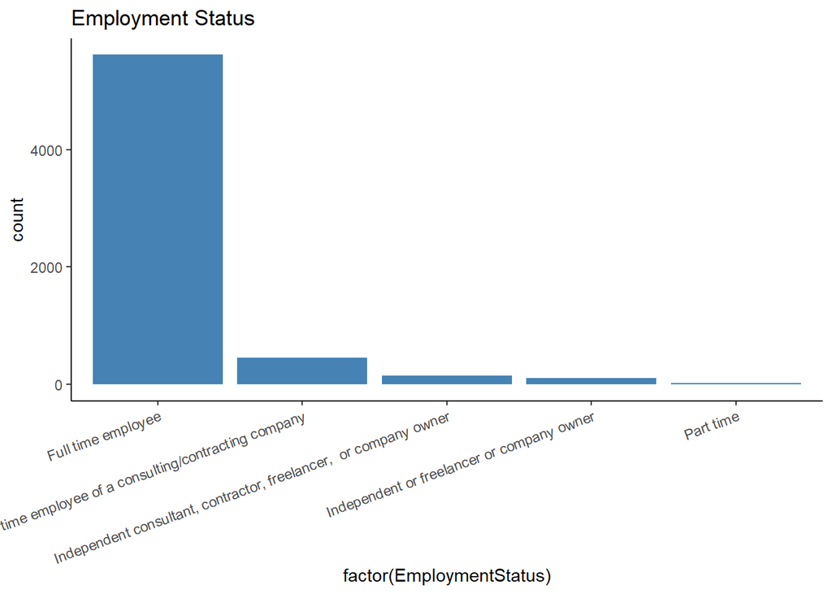

```r
# Barcharts of discrete data to visualize the segments

# Employee Status
ggplot(cleanDataSalary, aes(x = factor(EmploymentStatus))) +
  geom_bar(fill = "steelblue", alpha = 1) +
  theme_classic() +
  theme(axis.text.x= element_text(angle = 20, hjust= 1)) +
  ggtitle("Employment Status")
```

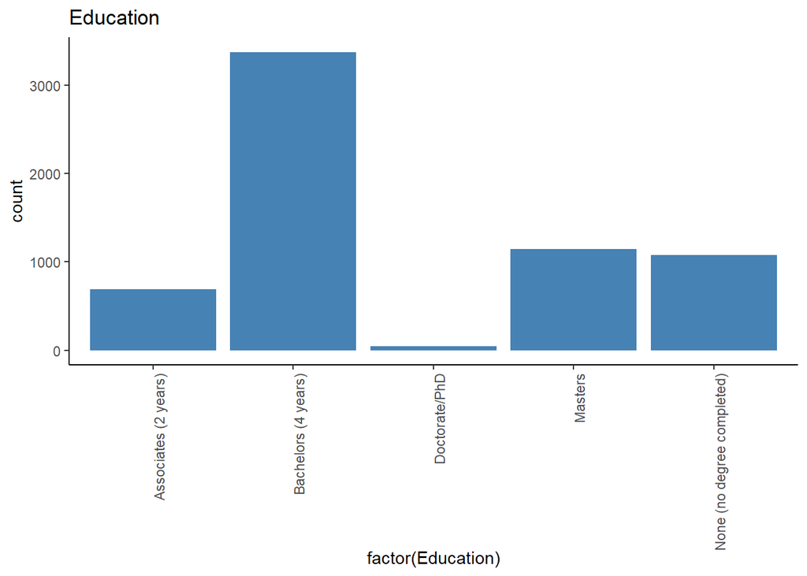

```r
# Education
ggplot(cleanDataSalary, aes(x = factor(Education))) +
  geom_bar(fill = "steelblue", alpha = 1) +
  theme_classic() +
  theme(axis.text.x= element_text(angle = 90, hjust= 1)) +
  ggtitle("Education")
```

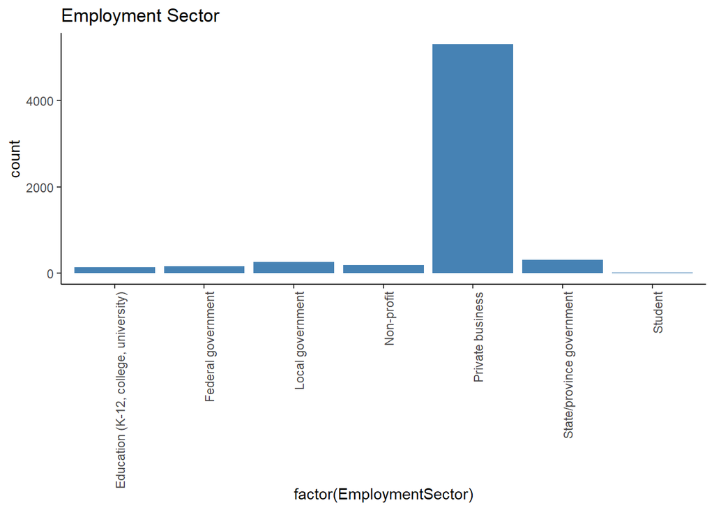

```r
# Employment Sector
ggplot(cleanDataSalary, aes(x = factor(EmploymentSector))) +
  geom_bar(fill = "steelblue", alpha = 1) +
  theme_classic() +
  theme(axis.text.x= element_text(angle = 90, hjust= 1)) +
  ggtitle("Employment Sector")
```

```r
# Calculate new descriptive statistics for SalaryUSD to contrast with the original dataset
mean(cleanDataSalary$SalaryUSD, na.rm =T) # The average salary is $91,151.88 lower avg
```

```
## [1] 91151.88
```

```r
sd(cleanDataSalary$SalaryUSD, na.rm =T) # The std dev of salaries is $41,425.04 lower std dev
```

```
## [1] 41425.04
```

```r
median(cleanDataSalary$SalaryUSD, na.rm =T) # The median salary is $90,000.00 No change
```

```
## [1] 90000
```

```r
max(cleanDataSalary$SalaryUSD, na.rm =T) # The maximum salary is $500,000
```

```
## [1] 5e+05
```

```r
min(cleanDataSalary$SalaryUSD, na.rm =T) # The minimum is $1050
```

```
## [1] 1050
```

```r
quantile(cleanDataSalary$SalaryUSD, na.rm =T) # The middle 50% of salaries fall between $65,000 to $115,000 No change
```

```
##     0%    25%    50%    75%   100%
##   1050  65000  90000 115000 500000
```

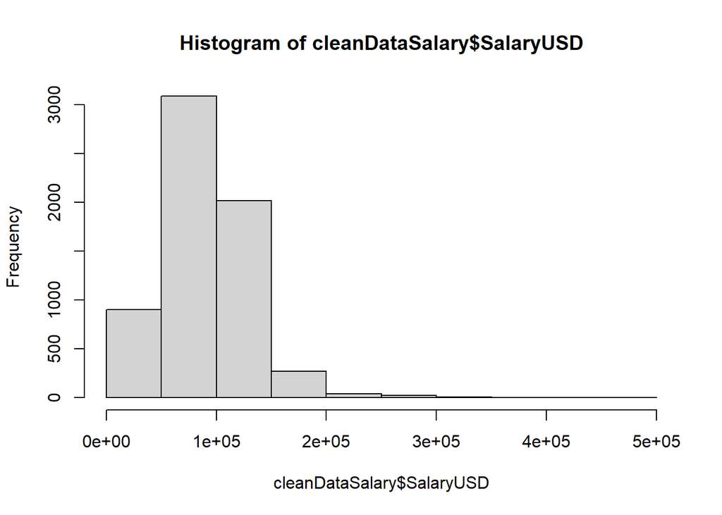

```r
# Create a histogram of $SalaryUSD
hist(cleanDataSalary$SalaryUSD)
```

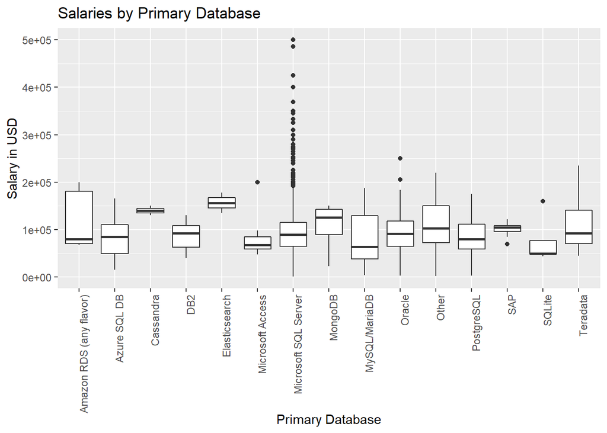

```r
# Create boxplots for SalaryUSD grouped by Primary Database
cleanDataSalary %>%
  ggplot() +
  aes(x=PrimaryDatabase, y=SalaryUSD)+
  geom_boxplot()+
  theme(axis.text.x= element_text(angle = 90, hjust= 1)) +
  ggtitle("Salaries by Primary Database") +
  xlab("Primary Database") + ylab("Salary in USD")
```

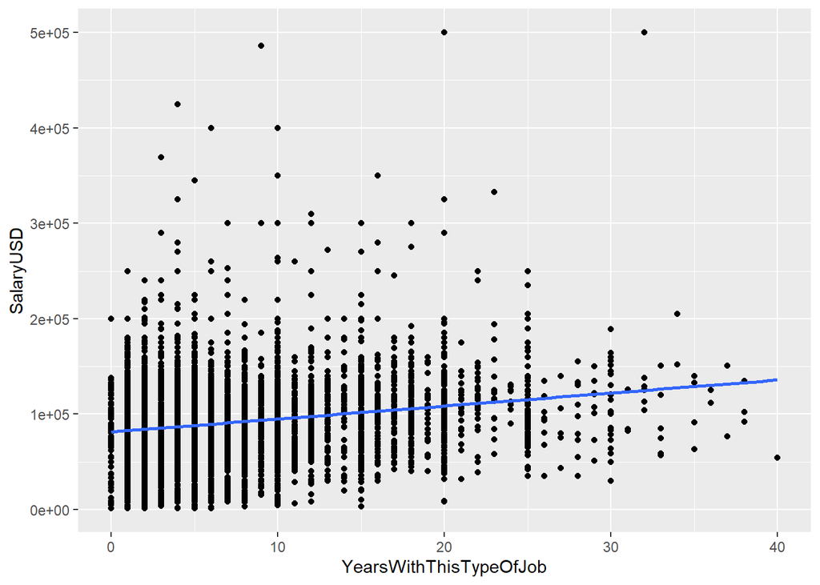

```r
# Scatter Plot of SalaryUSD by YearsWithThisTypeOfJob
salaryScatter1 <- cleanDataSalary %>%
  ggplot() +
  aes(x=YearsWithThisTypeOfJob, y=SalaryUSD)+
  geom_point(aes())

# Create a best fit line for salaryScatter
salaryScatter1 + geom_smooth(method="lm", se=FALSE)
```

## Linear Regression Code

```r
# Create a Linear Model to predict Salary
lmOut <- lm(SalaryUSD ~ ManageStaff +
              Country +
              PrimaryDatabase +
              YearsWithThisTypeOfJob +
              EmploymentStatus +
              JobTitle +
              OtherPeopleOnYourTeam +
              DatabaseServers +
              Education +
              EducationIsComputerRelated +
              Certifications +
              EmploymentSector,
            data = cleanDataSalary
)
summary(lmOut)
```

```
##
## Call:
## lm(formula = SalaryUSD ~ ManageStaff + Country + PrimaryDatabase +
##     YearsWithThisTypeOfJob + EmploymentStatus + JobTitle + OtherPeopleOnYourTeam +
##     DatabaseServers + Education + EducationIsComputerRelated +
##     Certifications + EmploymentSector, data = cleanDataSalary)
##
## Residuals:
##     Min      1Q  Median      3Q     Max
## -119347  -15465   -1809   12520  399690
##
## Coefficients:
##                                                                                                                      Estimate
## (Intercept)                                                                                                        -2.322e+04
## ManageStaffYes                                                                                                      8.920e+03
## CountryArgentina                                                                                                    8.325e+03
## CountryAustralia                                                                                                    7.593e+04
## CountryAustria                                                                                                      4.407e+04
## CountryBahrain                                                                                                      6.082e+04
## CountryBelarus                                                                                                      1.510e+04
## CountryBelgium                                                                                                      3.486e+04
## CountryBermuda                                                                                                      8.799e+04
## CountryBolivia                                                                                                      9.689e+03
## CountryBrazil                                                                                                       1.372e+04
## CountryBulgaria                                                                                                     2.162e+04
## CountryCanada                                                                                                       5.959e+04
## CountryCayman Islands                                                                                               7.793e+04
## CountryChina                                                                                                        3.528e+04
## CountryColombia                                                                                                    -1.729e+04
## CountryCosta Rica                                                                                                   3.152e+04
## CountryCroatia                                                                                                      5.387e+02
## CountryCzech Republic                                                                                               1.705e+04
## CountryDenmark                                                                                                      7.763e+04
## CountryEcuador                                                                                                      1.957e+04
## CountryEl Salvador                                                                                                  2.135e+04
## CountryEstonia                                                                                                      1.573e+04
## CountryFinland                                                                                                      4.171e+04
## CountryFrance                                                                                                       3.654e+04
## CountryGermany                                                                                                      5.365e+04
## CountryGreece                                                                                                       1.519e+04
```

[output cut: 693 more lines]

```
## EducationIsComputerRelatedYes
## CertificationsYes, and they're currently valid                                                                     ***
## CertificationsYes, but they expired                                                                                ***
## EmploymentSectorFederal government                                                                                 ***
## EmploymentSectorLocal government                                                                                   *
## EmploymentSectorNon-profit                                                                                         ***
## EmploymentSectorPrivate business                                                                                   ***
## EmploymentSectorState/province government                                                                          **
## EmploymentSectorStudent
## ---
## Signif. codes:  0 '***' 0.001 '**' 0.01 '*' 0.05 '.' 0.1 ' ' 1
##
## Residual standard error: 28630 on 6198 degrees of freedom
## Multiple R-squared:  0.5331, Adjusted R-squared:  0.5223
## F-statistic: 49.15 on 144 and 6198 DF,  p-value: < 2.2e-16
```

```r
# Data Interpretation
# This model accounts for 52.2% of the effects on salary
# Using this model we can predict a salary based on the following statistically significant attributes
lmIntercept <- -23224.07
lmCountry <- 89463.73 #US
lmYearsExp <- 1007.5*3 #Number of years working that type of job
lmEmpStatus <- 57672.43 #Ind Contractor or Company Owner
lmJobTitle <- 26035.85 #Data Scientist
lmEducation <- 9129.92 #Masters
lmCertification <- 7463.64 #Yes but expired
lmSector <- 24341 #Federal Gov't

lmSalaryPrediction <- lmIntercept + lmCountry + lmYearsExp + lmEmpStatus + lmJobTitle + lmEducation + lmCertification + lmSector
lmSalaryPrediction # $193,905
```

```
## [1] 193905
```

```r
dev.off() # Clear the graph window
```

```r
rm(list=ls()) # Clear user objects from the environment
cat('\014')  # Clear the console
```